# Math 189: Resampling II

## Leave-One-Out Cross Validation

- Leave-one-out cross-validation (LOOCV) is closely related to the validation set approach. It attempts to address the drawbacks of the latter.
- Instead of randomly dividing the sample into a training set and a validation set, LOOCV doesit in an alternating way:
1. Pick the first observation $(x_1, y_1)$ as the validation set, and use the remaining observations $(x_2,y_2), \ldots, (x_n, y_n)$ as the training set. The testing error is measured as
   $$\mbox{MSPE}_1 = {(y_1 - \widehat{y}_1 )}^2.$$
2. Pick $(x_2, y_2)$ as the validation set, and use the remaining observations as the training set. The testing error is measured as
   $$\mbox{MSPE}_2 = {(y_2 - \widehat{y}_2 )}^2.$$
3. Repeat for each observation in the sample and obtain
   $$\mbox{MSPE}_i = {(y_i - \widehat{y}_i )}^2.$$
4. The tesing error is the average of the mean square prediction errors:
   $$\frac{1}{n} \sum_{i=1}^n \mbox{MSPE}_i = \frac{1}{n} \sum_{i=1}^n
   {(y_i - \widehat{y}_i )}^2.$$

## Leave-one-out CV versus Validation Set

### Leave-one-out CV

- Repeatedly fit the statistical learning method using training sets that contain $n-1$ observations.
- Less bias, because the training set is close to the whole sample.
- Avoid overestimating the test error.
- Yield same results when applied multiple times.
- Expensive computational cost, as the model has to be fit $n$ times.

### Validation set

- Fit the statistical learning method using a random sub-sample.
- Large bias, as we used smaller sample size to train the model.
- May over-estimate the test error.
- Yield different results when applied repeatedly, due to random training-validation splitting.
- Fast computation, because model is only trained once.

## $K$-fold Cross Validation

- An alternative to LOOCV is $K$-fold CV. This approach involves randomly dividing the set of observations into $K$ groups, or folds, of approximately equal size.
- $K$-fold CV also works in a repeated way:
1. Pick the first fold as the validation set, and use the remaining $K-1$ folds as the training set. The test error $\mbox{MSPE}_1$ is computed on the observations in first fold.
2. Repeat step 1 by using each fold as the validation set and use the remaining $K-1$ folds as the training set. The test errors $\mbox{MSPE}_2, \ldots, \mbox{MSPE}_K$ are computed on the observations in the held-out fold.
3. The tesing error is the average of the mean square prediction errors:
   $$\frac{1}{K} \sum_{j=1}^K \mbox{MSPE}_j.$$
- LOOCV can be considered as a special $K$-fold CV with $K = n$.
- In practice, we usually perform $K$-fold CV using $K=5$ or $K= 10$.

## Advantages of $K$-fold Cross Validation

- Both LOOCV and $K$-fold CV are very general resampling methods, and can be used on many kinds of predictive learning processes.
- In general, $K$-fold CV (with $K=5$ or $K= 10$) is more popular than LOOCV.
- What are the advantages of $K$-fold CV?

### First Advantage

- The most obvious advantage is *computational feasibility*.
- LOOCV requires fitting the statistical learning method $n$ times. This has the potential to be computationally expensive when $n$ is large, or fitting is computationally intensive.
- $K$-fold CV only requires fitting the statistical learning method $K$ times.

### Second Advantage

- A less obvious but potentially more important advantage of $K$-fold CV is that it often gives more accurate estimates of the testing error rate than LOOCV. This has to do with a *bias-variance* trade-off.

## Bias-Variance Trade-off in Cross Validation

### Bias:

- The validation set approach tends to have large bias. The model is trained with a smaller sample size. The validation set approach tends to overestimate the test error.
- Using this logic, the LOOCV will give approximately unbiased estimates of the test error. Each training set contains $n-1$ observations, which is almost as many as the number of observations in the full dataset.
- And performing $K$-fold CV will lead to an intermediate level of bias. Each training set contains $(K-1) n/K$ observations; fewer than in the LOOCV approach, but substantially more than in the validation set approach.

### Variance:

- On the other hand, LOOCV has a high level of variance.
1. When we perform LOOCV, we are in effect averaging the outputs of $n$ fitted models, each of which is trained on an almost identical set of observations; therefore, these outputs are highly (positively) correlated with each other.
2. The mean of many highly correlated quantities has higher variance than the mean of many variables that are less correlated.
- In contrast, $K$-fold CV with $K < n$ has a smaller variance. We are averaging the outputs of $K$ fitted models that are somewhat less correlated with each other, since the overlap between the training sets in each model is smaller.

### Summary of Trade-off

- To summarize, there is a bias-variance trade-off associated with the choice of $K$ in $K$-fold CV.
- Typically, given these considerations, popular choices of $K =5$ or $K= 10$ have been shown empirically to yield test error estimates that suffer neither from excessively high bias nor from very high variance.

## Example: Predict MPG with Horsepower

- We return to the automobiles dataset.
- Now we compare the test errors estimated by LOOCV and $8$-fold CV (I chose $K=8$ because it divides $n = 392$).

```r
library(ISLR)
head(Auto)
```

```
##   mpg cylinders displacement horsepower weight acceleration year origin
## 1  18         8          307        130   3504         12.0   70      1
## 2  15         8          350        165   3693         11.5   70      1
## 3  18         8          318        150   3436         11.0   70      1
## 4  16         8          304        150   3433         12.0   70      1
## 5  17         8          302        140   3449         10.5   70      1
## 6  15         8          429        198   4341         10.0   70      1
##                        name
## 1 chevrolet chevelle malibu
## 2         buick skylark 320
## 3        plymouth satellite
## 4             amc rebel sst
## 5               ford torino
## 6          ford galaxie 500
```

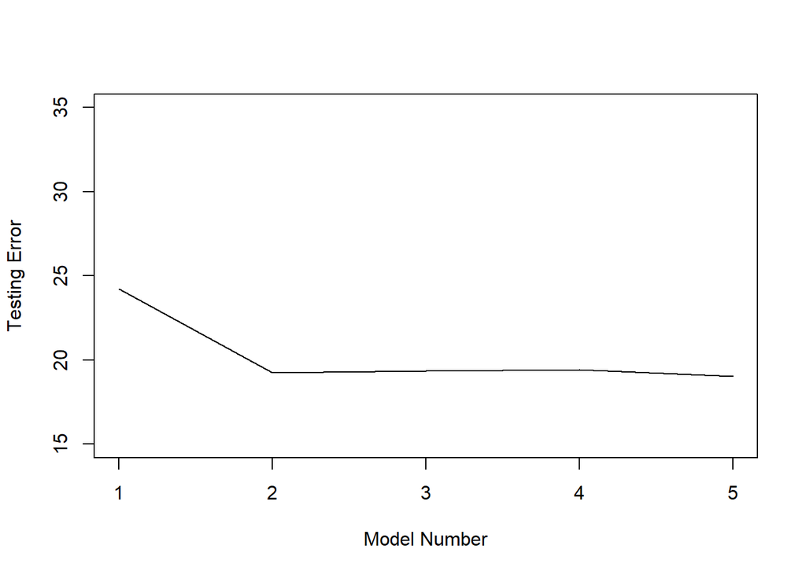

```r
# LOOCV
perf_loocv <- rep(0,5)
for(count in 1:392)
{

test_ind <- setdiff(seq(1,392),count)
val_ind <- count
Auto_test <- Auto[test_ind,]
Auto_val <- Auto[val_ind,]

# Train
y <- Auto_test$mpg
x <- Auto_test$horsepower
x2 <- x^2
x3 <- x^3
x4 <- x^4
x5 <- x^5
mdl1 <- lm(y ~ x)
mdl2 <- lm(y ~ x + x2)
mdl3 <- lm(y ~ x + x2 + x3)
mdl4 <- lm(y ~ x + x2 + x3 + x4)
mdl5 <- lm(y ~ x + x2 + x3 + x4 + x5)
train_err <- rep(0,5)
train_err[1] <- mean((y - mdl1$fitted.values)^2)
train_err[2] <- mean((y - mdl2$fitted.values)^2)
train_err[3] <- mean((y - mdl3$fitted.values)^2)
train_err[4] <- mean((y - mdl4$fitted.values)^2)
train_err[5] <- mean((y - mdl5$fitted.values)^2)

# Test
y <- Auto_val$mpg
x <- Auto_val$horsepower
z1 <- (mdl1$coefficients[1] + mdl1$coefficients[2]*x)
z2 <- (mdl2$coefficients[1] + mdl2$coefficients[2]*x + mdl2$coefficients[3]*x^2)
z3 <- (mdl3$coefficients[1] + mdl3$coefficients[2]*x + mdl3$coefficients[3]*x^2 +
       mdl3$coefficients[4]*x^3)
z4 <- (mdl4$coefficients[1] + mdl4$coefficients[2]*x + mdl4$coefficients[3]*x^2 +
       mdl4$coefficients[4]*x^3 + mdl4$coefficients[5]*x^4)
z5 <- (mdl5$coefficients[1] + mdl5$coefficients[2]*x + mdl5$coefficients[3]*x^2 +
       mdl5$coefficients[4]*x^3 + mdl5$coefficients[5]*x^4 + mdl5$coefficients[6]*x^5)
test_err <- rep(0,5)
test_err[1] <- mean((y - z1)^2)
test_err[2] <- mean((y - z2)^2)
test_err[3] <- mean((y - z3)^2)
test_err[4] <- mean((y - z4)^2)
test_err[5] <- mean((y - z5)^2)

perf_loocv <- perf_loocv + test_err/392
}

plot.ts(perf_loocv,xlab="Model Number",ylab="Testing Error",ylim=c(15,35))
```

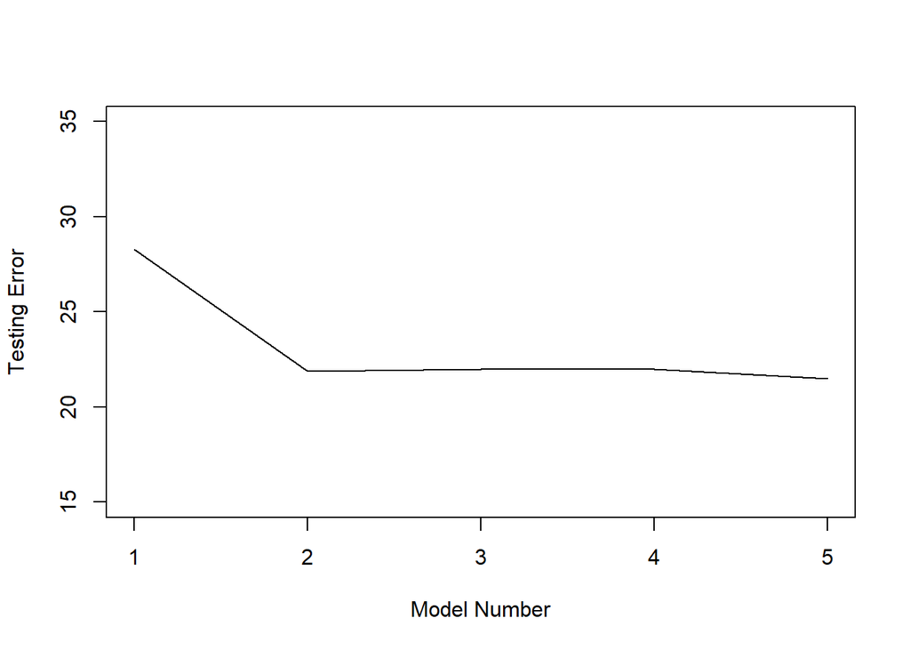

```r
# K-fold CV
k <- 8
folds <- matrix(seq(1,392),ncol=8)
perf_kcv <- rep(0,5)
for(count in 1:k)
{
test_ind <- folds[,-count]
val_ind <- folds[,count]
Auto_test <- Auto[test_ind,]
Auto_val <- Auto[val_ind,]

# Train
y <- Auto_test$mpg
x <- Auto_test$horsepower
x2 <- x^2
x3 <- x^3
x4 <- x^4
x5 <- x^5
mdl1 <- lm(y ~ x)
mdl2 <- lm(y ~ x + x2)
mdl3 <- lm(y ~ x + x2 + x3)
mdl4 <- lm(y ~ x + x2 + x3 + x4)
mdl5 <- lm(y ~ x + x2 + x3 + x4 + x5)
train_err <- rep(0,5)
train_err[1] <- mean((y - mdl1$fitted.values)^2)
train_err[2] <- mean((y - mdl2$fitted.values)^2)
train_err[3] <- mean((y - mdl3$fitted.values)^2)
train_err[4] <- mean((y - mdl4$fitted.values)^2)
train_err[5] <- mean((y - mdl5$fitted.values)^2)

# Test
y <- Auto_val$mpg
x <- Auto_val$horsepower
z1 <- (mdl1$coefficients[1] + mdl1$coefficients[2]*x)
z2 <- (mdl2$coefficients[1] + mdl2$coefficients[2]*x + mdl2$coefficients[3]*x^2)
z3 <- (mdl3$coefficients[1] + mdl3$coefficients[2]*x + mdl3$coefficients[3]*x^2 +
       mdl3$coefficients[4]*x^3)
z4 <- (mdl4$coefficients[1] + mdl4$coefficients[2]*x + mdl4$coefficients[3]*x^2 +
       mdl4$coefficients[4]*x^3 + mdl4$coefficients[5]*x^4)
z5 <- (mdl5$coefficients[1] + mdl5$coefficients[2]*x + mdl5$coefficients[3]*x^2 +
       mdl5$coefficients[4]*x^3 + mdl5$coefficients[5]*x^4 + mdl5$coefficients[6]*x^5)
test_err <- rep(0,5)
test_err[1] <- mean((y - z1)^2)
test_err[2] <- mean((y - z2)^2)
test_err[3] <- mean((y - z3)^2)
test_err[4] <- mean((y - z4)^2)
test_err[5] <- mean((y - z5)^2)

perf_kcv <- perf_kcv + test_err/k
}

plot.ts(perf_kcv,xlab="Model Number",ylab="Testing Error",ylim=c(15,35))
```

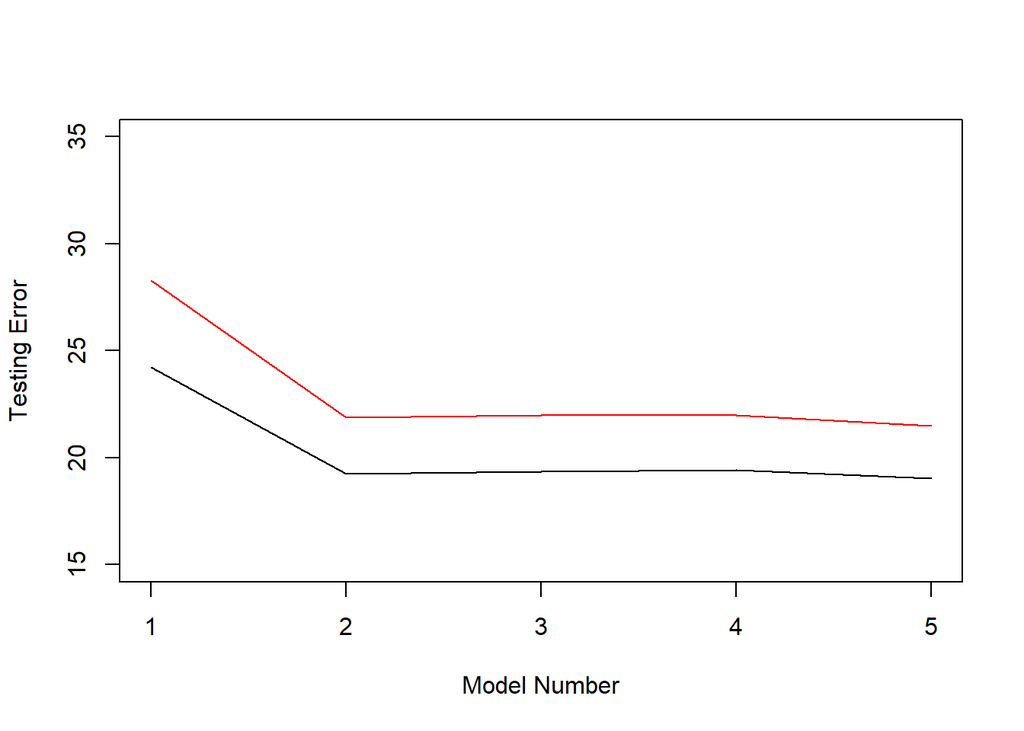

```r
plot.ts(perf_loocv,xlab="Model Number",ylab="Testing Error",ylim=c(15,35))
lines(perf_kcv,col=2)
```

## Cross Validation on Classification Problems

- We have illustrated the use of cross-validation in the regression setting where the outcome $y$ is quantitative. The test error is quantified by the $\mbox{MSPE}$.
- Cross-validation can also be a very useful approach in the classification setting, when $y$ is qualitative (or categorical).
- In classification problems, we can quantify test error by the number of misclassified observations.
- For instance, in the classification setting, the LOOCV error takes the form
  $$\mbox{CV}_{(n)} = \frac{1}{n} \sum_{i=1}^n 1_{ \{ y_i \neq \widehat{y}_i \}},$$
  where $1_{ \{ y_i \neq \widehat{y}_i \}}$ equals $1$ if $y_i \neq \widehat{y}_i$ and is zero if $y_i = \widehat{y}_i$.
- The $K$-fold CV error takes the form
  $$\mbox{CV}_{(K)} = \frac{1}{K} \sum_{i=1}^K \sum_{j=1}^{n_i}
  1_{ \{ y_j \neq \widehat{y}_j \}},$$
  where $n_i$ is the sample size of the $i$th fold.